# Insurance customer churn prediction

We also visualize the ROC:

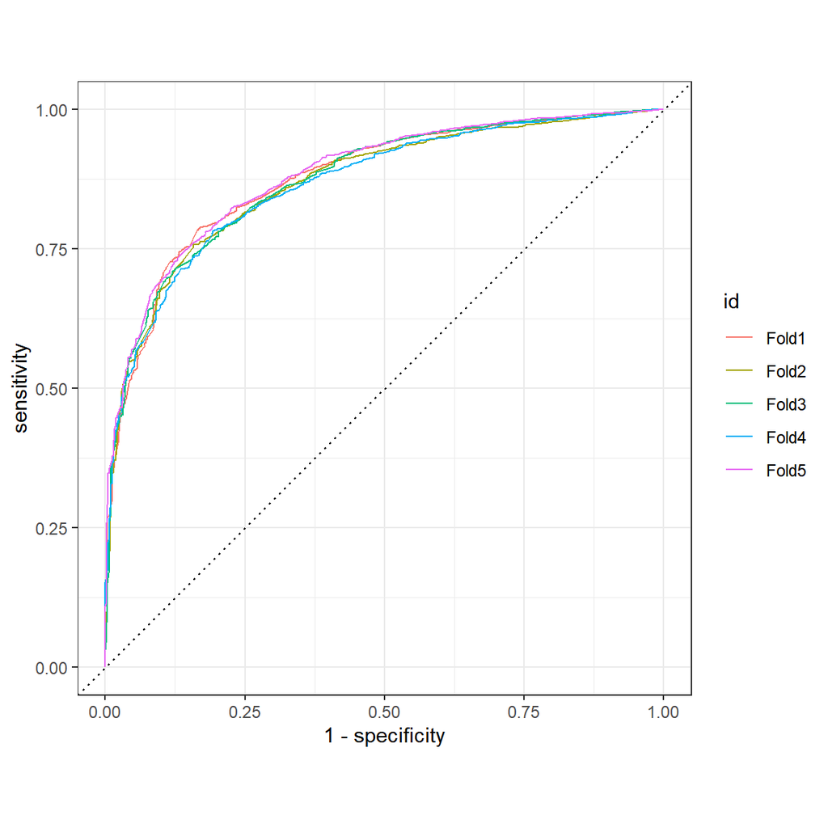

```r
xgb_pred %>%
  group_by(id) %>% # id contains our folds
  roc_curve(churn, .pred_0) %>%
  autoplot()
```

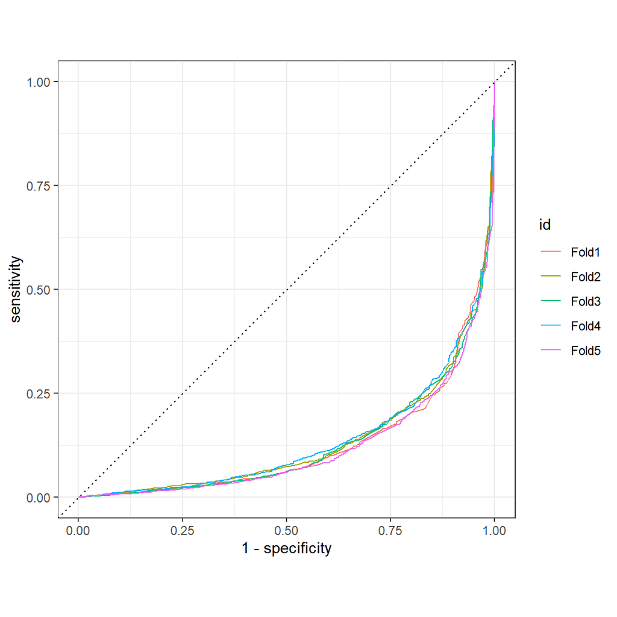

```r
xgb_pred %>%
  group_by(id) %>% # id contains our folds
  roc_curve(churn, .pred_1) %>%
  autoplot()
```

Our model is very good at predicting that a customer won’t churn (first ROC-curve) but at the same time worse than random guessing (would be a ROC-curve at 45 degrees) if a customer will churn (second ROC-curve).

For our use case we need to make sure that the model has a better specificity since we want to show the cases that are likely to churn.

In order to find a better model we will train and evaluate some other classifying algorithms and compare all models using the f1 score as a performance measure.

# 5 Additional model training

We will use the following algorithms

- Logistic regression
- Random forest
- K-nearest neighbor

We repeat all our steps from above to create specifications, workflows and train the models.

```r
# Logistic regression
log_spec <-
  # will use best empirical hyperparamters
  logistic_reg() %>%
  set_engine(engine = "glm") %>%
  set_mode("classification")

# Random forest
rf_spec <-
  # will use best empirical hyperparamters
  rand_forest() %>%
  set_engine("ranger") %>%
  set_mode("classification")

# K-nearest neighbor
knn_spec <-
  # will use best empirical hyperparamters
  nearest_neighbor(neighbors = 4) %>% # can be adjusted
  set_engine("kknn") %>%
  set_mode("classification")
```

```r
# Logistic regression
log_wflow <-
 workflow() %>%
 add_recipe(churn_rec) %>%
 add_model(log_spec)

# Random forest
rf_wflow <-
 workflow() %>%
 add_recipe(churn_rec) %>%
 add_model(rf_spec)

# K-nearest neighbor
knn_wflow <-
 workflow() %>%
 add_recipe(churn_rec) %>%
 add_model(knn_spec)
```

```r
# Logistic regression
log_res <-
  log_wflow %>%
  fit_resamples(
    resamples = cv_folds,
    # Define metrics
    metrics = metric_set(
      f_meas,
      accuracy,
      roc_auc,
      recall,
      precision,
      spec,
      sens,
      ),
    # Save predictions
    control = control_resamples(save_pred = TRUE)
  )


# Random forest
rf_res <-
  rf_wflow %>%
  fit_resamples(
    resamples = cv_folds,
    # Define metrics
    metrics = metric_set(
      f_meas,
      accuracy,
      roc_auc,
      recall,
      precision,
      spec,
      sens,
      ),
    # Save predictions
    control = control_resamples(save_pred = TRUE)
  )

# K-nearest neighbor
knn_res <-
  knn_wflow %>%
  fit_resamples(
    resamples = cv_folds,
    # Define metrics
    metrics = metric_set(
      f_meas,
      accuracy,
      roc_auc,
      recall,
      precision,
      spec,
      sens,
      ),
    # Save predictions
    control = control_resamples(save_pred = TRUE)
  )
```

## 5.1 Model comparison

We compare the models by first looking at the different metrics and the confusion matrices.

- Logistic regression

```r
log_res %>%  collect_metrics(summarize = TRUE)
```

| .metric | .estimator | mean | n | std_err | .config |
| --- | --- | --- | --- | --- | --- |
| accuracy | binary | 0.8895006 | 5 | 0.0014055105 | Preprocessor1_Model1 |
| f_meas | binary | 0.9400413 | 5 | 0.0008199320 | Preprocessor1_Model1 |
| precision | binary | 0.9023514 | 5 | 0.0006736814 | Preprocessor1_Model1 |
| recall | binary | 0.9810287 | 5 | 0.0019569426 | Preprocessor1_Model1 |
| roc_auc | binary | 0.8594903 | 5 | 0.0028509044 | Preprocessor1_Model1 |
| sens | binary | 0.9810287 | 5 | 0.0019569426 | Preprocessor1_Model1 |
| spec | binary | 0.1986555 | 5 | 0.0069377370 | Preprocessor1_Model1 |

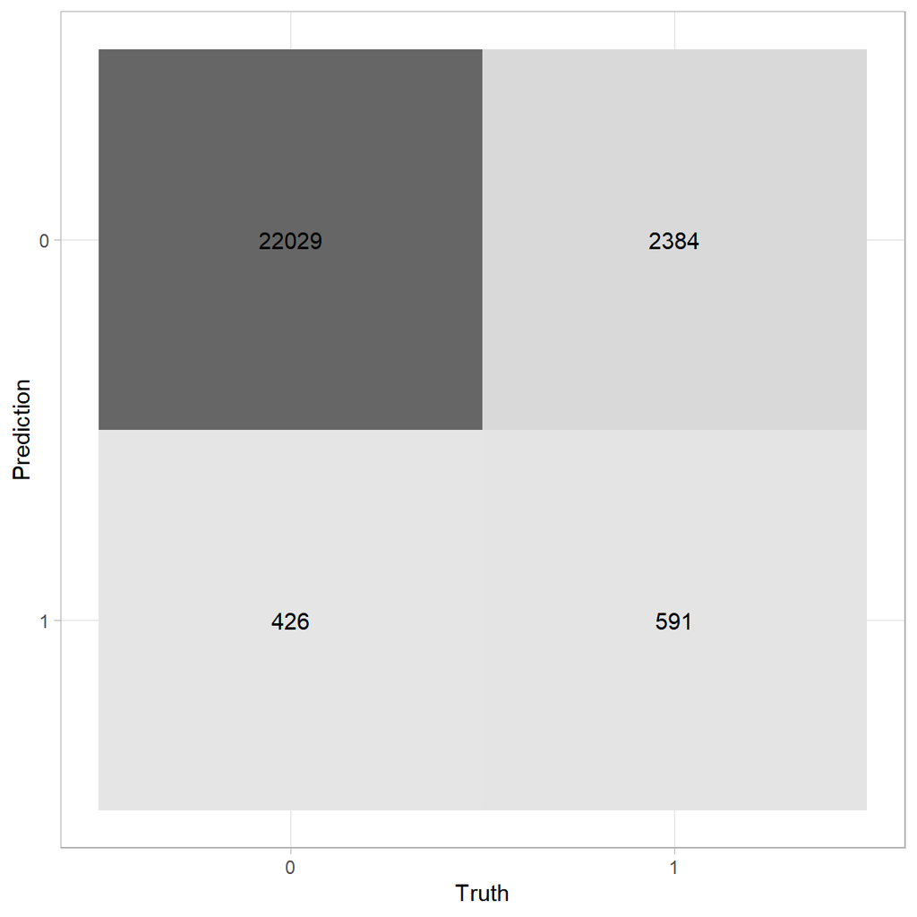

```r
log_pred <-
  log_res %>%
  collect_predictions()

log_pred %>%
  conf_mat(churn, .pred_class) %>%
  autoplot("heatmap")
```

- Random forest

```r
rf_res %>%  collect_metrics(summarize = TRUE)
```

| .metric | .estimator | mean | n | std_err | .config |
| --- | --- | --- | --- | --- | --- |
| accuracy | binary | 0.8909949 | 5 | 0.0016932010 | Preprocessor1_Model1 |
| f_meas | binary | 0.9403710 | 5 | 0.0009361867 | Preprocessor1_Model1 |
| precision | binary | 0.9095026 | 5 | 0.0010142064 | Preprocessor1_Model1 |
| recall | binary | 0.9734135 | 5 | 0.0013826920 | Preprocessor1_Model1 |
| roc_auc | binary | 0.8715515 | 5 | 0.0023576812 | Preprocessor1_Model1 |
| sens | binary | 0.9734135 | 5 | 0.0013826920 | Preprocessor1_Model1 |
| spec | binary | 0.2689076 | 5 | 0.0088295298 | Preprocessor1_Model1 |

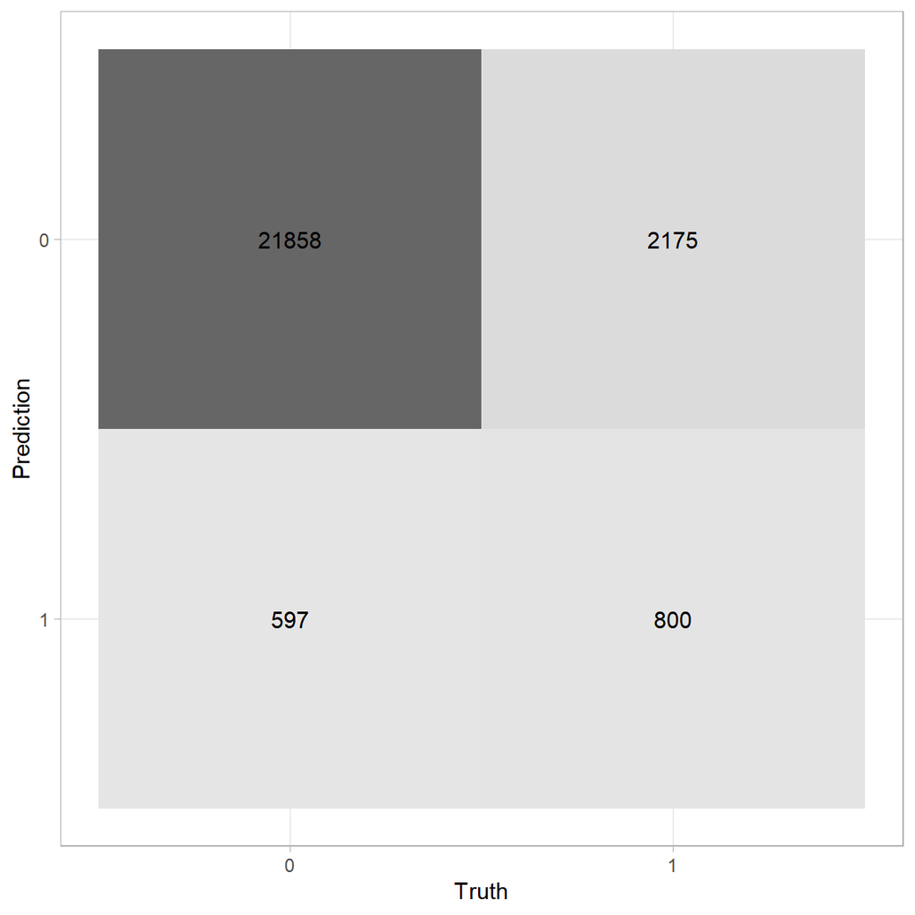

```r
rf_pred <-
  rf_res %>%
  collect_predictions()

rf_pred %>%
  conf_mat(churn, .pred_class) %>%
  autoplot(type = "heatmap")
```

- K-nearest neighbor

```r
knn_res %>%  collect_metrics(summarize = TRUE)
```

| .metric | .estimator | mean | n | std_err | .config |
| --- | --- | --- | --- | --- | --- |
| accuracy | binary | 0.8809280 | 5 | 0.0013285919 | Preprocessor1_Model1 |
| f_meas | binary | 0.9347077 | 5 | 0.0007839021 | Preprocessor1_Model1 |
| precision | binary | 0.9060351 | 5 | 0.0006065056 | Preprocessor1_Model1 |
| recall | binary | 0.9652639 | 5 | 0.0017855106 | Preprocessor1_Model1 |
| roc_auc | binary | 0.7547684 | 5 | 0.0036814654 | Preprocessor1_Model1 |
| sens | binary | 0.9652639 | 5 | 0.0017855106 | Preprocessor1_Model1 |
| spec | binary | 0.2443697 | 5 | 0.0060270323 | Preprocessor1_Model1 |

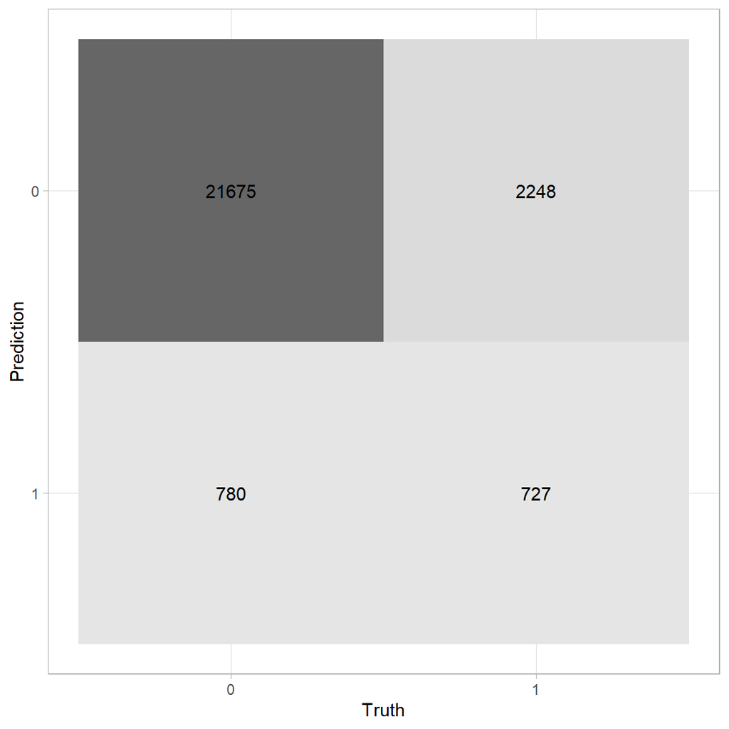

```r
knn_pred <-
  knn_res %>%
  collect_predictions()

knn_pred %>%
  conf_mat(churn, .pred_class) %>%
  autoplot(type = "heatmap")
```

- XGBoost

```r
xgb_res %>% collect_metrics(summarize = TRUE)
```

| .metric | .estimator | mean | n | std_err | .config |
| --- | --- | --- | --- | --- | --- |
| accuracy | binary | 0.8924105 | 5 | 0.0015056382 | Preprocessor1_Model1 |
| f_meas | binary | 0.9408938 | 5 | 0.0008361253 | Preprocessor1_Model1 |
| precision | binary | 0.9136662 | 5 | 0.0012743246 | Preprocessor1_Model1 |
| recall | binary | 0.9698063 | 5 | 0.0016035156 | Preprocessor1_Model1 |
| roc_auc | binary | 0.8733081 | 5 | 0.0028505687 | Preprocessor1_Model1 |

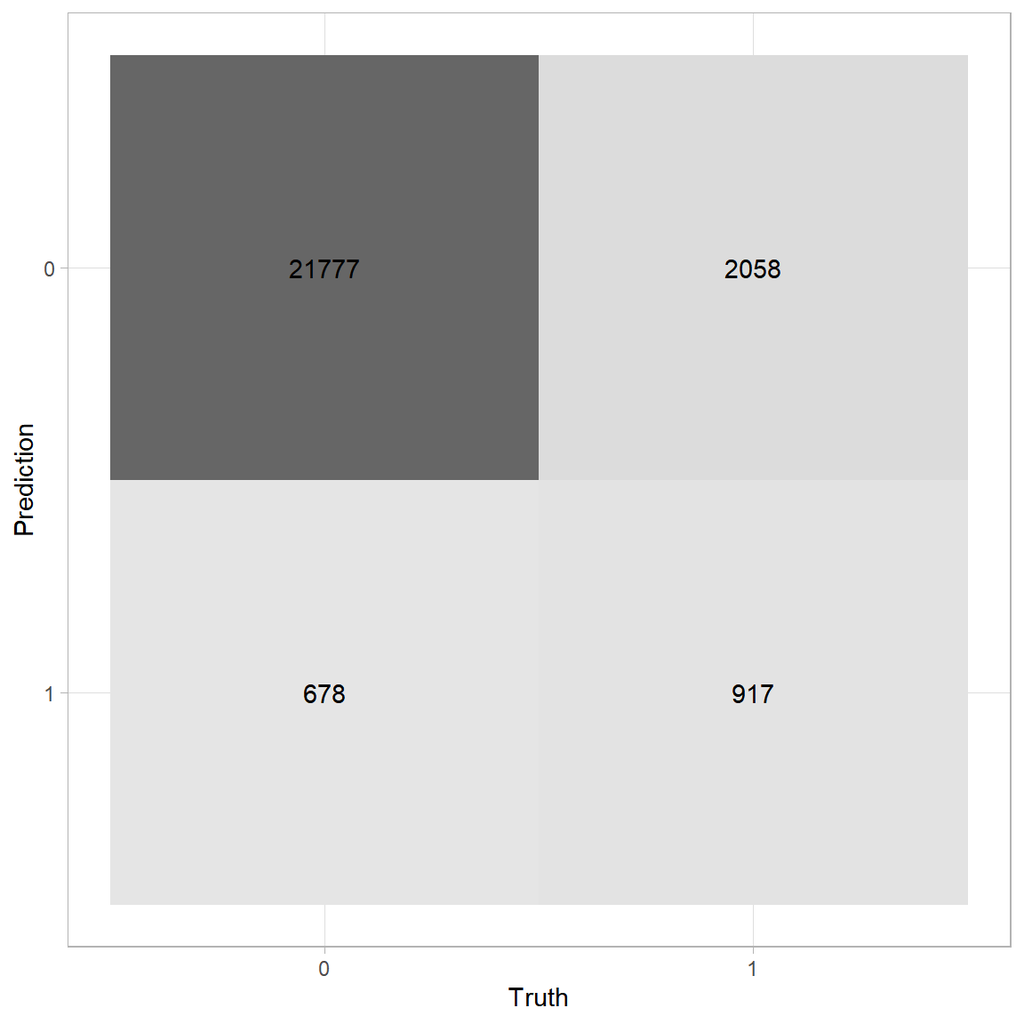

```r
xgb_pred %>%
  conf_mat(churn, .pred_class) %>%
  autoplot("heatmap")
```

We can see that our xgboost classification algorithm performed the best out of all models so far, considering specificity and F1-Score.

We will use that model and fine tune it in order to gain a better specificity and thus a higher prediction for churning.

# 6 Model fine tuning

```r
smote_data <-
  #performanceEstimation::
  smote(churn ~., train_data, perc.over = 4, perc.under = 2)

table(smote_data$churn)
```

```
##
##     0     1
## 23800 14875
```

The data ist still imbalanced, but not as much as before.

We will also need to create a new evaluation set with the adjusted dataset.

```r
# Fix random generation, also see data split
set.seed(42)
# generate the cross validation set
cv_folds <-
  vfold_cv(smote_data,
           v=5, # number of folds
           strata = churn, # ensure the same proportion of the churn variable in every fold
           breaks = 4)
```

Now all we have to do is perform hyperparameter tuning our xgboost algorithm to select the best values to maximize specificity.

## 6.1 Model specification

We have to specify the hyperparameters that we want to tune. We also adjust for the rest of the imbalance by using the scale_pos_weight hyperparameter to tune.

```r
xgb_tuned_spec <-
  boost_tree(
      mtry = tune(), # number (or proportion) of predictors
      trees = 10, # number of decision trees. For testing, we will leave it at a lower value
      min_n = tune(), # minimum number of data points in a node required to split
      tree_depth = tune(), # maximum splits (depth of decision trees)
      learn_rate = tune(), # adaption rate over iterations
      loss_reduction = tune(), # reduction in loss required to split
      sample_size = tune(), # number (or proportion) of data exposed to fitting
  ) %>%
  # model engine
  # specifiy scale_pos_weight to account for the imbalanced dataset
  set_engine("xgboost", scale_pos_weight = tune()) %>%
  # model mode
  set_mode("classification")

# show model specification
xgb_tuned_spec
```

```
## Boosted Tree Model Specification (classification)
##
## Main Arguments:
##   mtry = tune()
##   trees = 10
##   min_n = tune()
##   tree_depth = tune()
##   learn_rate = tune()
##   loss_reduction = tune()
##   sample_size = tune()
##
## Engine-Specific Arguments:
##   scale_pos_weight = tune()
##
## Computational engine: xgboost
```

## 6.2 Workflow

Next we create a new workflow object.

```r
# workflow pipeline
xgb_tuned_wflow <-
  workflow() %>%
  # specifiy our recipe
  add_recipe(churn_rec) %>%
  # and our model
  add_model(xgb_tuned_spec)

# show workflow
xgb_tuned_wflow
```

```
## == Workflow ====================================================================
## Preprocessor: Recipe
## Model: boost_tree()
##
## -- Preprocessor ----------------------------------------------------------------
## 3 Recipe Steps
##
## * step_normalize()
## * step_zv()
## * step_corr()
##
## -- Model -----------------------------------------------------------------------
## Boosted Tree Model Specification (classification)
##
## Main Arguments:
##   mtry = tune()
##   trees = 10
##   min_n = tune()
##   tree_depth = tune()
##   learn_rate = tune()
##   loss_reduction = tune()
##   sample_size = tune()
##
## Engine-Specific Arguments:
##   scale_pos_weight = tune()
##
## Computational engine: xgboost
```

## 6.3 Grid search

In order to tune the parameters we first set up possible values for them. For efficiency reasons we use grid_latin_hypercube().  
For more information see:  
https://htmlpreview.github.io/?https://github.com/kirenz/tidymodels-in-r/blob/main/05-tidymodels-xgboost-tuning.html

```r
xgb_grid <- grid_latin_hypercube(
  scale_pos_weight(),
  tree_depth(),
  min_n(),
  loss_reduction(),
  sample_size = sample_prop(), # needs to be a proportion
  finalize(mtry(), smote_data), # different approach since mtry depends on number of predictors in data
  learn_rate(),
  size = 10
)

xgb_grid
```

| scale_pos_weight | tree_depth | min_n | loss_reduction | sample_size | mtry | learn_rate |
| --- | --- | --- | --- | --- | --- | --- |
| 1.0094105 | 8 | 30 | 4.765817e-03 | 0.4557190 | 3 | 1.084974e-07 |
| 0.9721138 | 4 | 17 | 4.971648e-05 | 0.5155472 | 5 | 5.083441e-07 |
| 0.9120729 | 14 | 35 | 6.290772e+00 | 0.1577490 | 2 | 3.801060e-05 |
| 0.9293959 | 5 | 26 | 1.536873e-08 | 0.2805113 | 5 | 4.914146e-03 |
| 1.1155895 | 3 | 17 | 6.259549e-07 | 0.5881710 | 6 | 1.962443e-02 |
| 0.8557061 | 2 | 39 | 7.928786e-05 | 0.9418189 | 1 | 4.014570e-06 |
| 1.1586668 | 11 | 11 | 7.984127e-01 | 0.8205488 | 4 | 7.629868e-10 |
| 0.8125802 | 13 | 24 | 2.331527e-07 | 0.6818812 | 4 | 1.249432e-08 |
| 1.1810461 | 8 | 8 | 5.127170e-02 | 0.2617997 | 3 | 3.793113e-04 |
| 1.0524317 | 10 | 2 | 5.926825e-10 | 0.7974722 | 2 | 2.223594e-09 |

## 6.4 Hyperparameter tuning

The tune_grid function computes the performance metrics for us, which we defined earlier.

```r
# Seeded to make sure we can reproduce the tuning
set.seed(42)

xgb_tuned_res <- tune_grid(
  xgb_tuned_wflow,
  resamples = cv_folds,
  grid = xgb_grid,
  # save the predictions to visualize the data
  metrics = metric_set(
      f_meas,
      accuracy,
      roc_auc,
      recall,
      precision
      ),
  control = control_grid(save_pred = TRUE)
)

xgb_tuned_res
```

| splits | id | .metrics | .notes | .predictions |
| --- | --- | --- | --- | --- |
|  | Fold1 |  |  |  |
|  | Fold2 |  |  |  |
|  | Fold3 |  |  |  |
|  | Fold4 |  |  |  |
|  | Fold5 |  |  |  |